# Does faculty salary vary by gender and/or rank?

## Set up

Before getting started, the only addtional library you should have to install (that did not come with the anaconda python distribution) is `seaborn`, a package for visualization. Execute this command on your terminal.

```
pip install seaborn
```

Let's begin by reading in some data from [this course website](http://data.princeton.edu/wws509/datasets/#salary). Columns included are:

- **sx** = Sex, coded 1 for female and 0 for male
- **rk** = Rank, coded
  - 1 for assistant professor,
  - 2 for associate professor, and
  - 3 for full professor
- **yr** = Number of years in current rank
- **dg** = Highest degree, coded 1 if doctorate, 0 if masters
- **yd** = Number of years since highest degree was earned
- **sl** = Academic year salary, in dollars.

```
sx    object
rk    object
yr     int64
dg    object
yd     int64
sl     int64
dtype: object
```

## Descriptive statistics by gender

Before doing any statistical tests, you should get a basic feel for the gender breakdown in your dataset

```
sx
female    14
male      38
dtype: int64
```

| sx | sl |
| --- | --- |
| female | 21357.142857 |
| male | 24696.789474 |

```
array([<matplotlib.axes._subplots.AxesSubplot object at 0x1a18407048>,
       <matplotlib.axes._subplots.AxesSubplot object at 0x1a1840b2b0>], dtype=object)
```

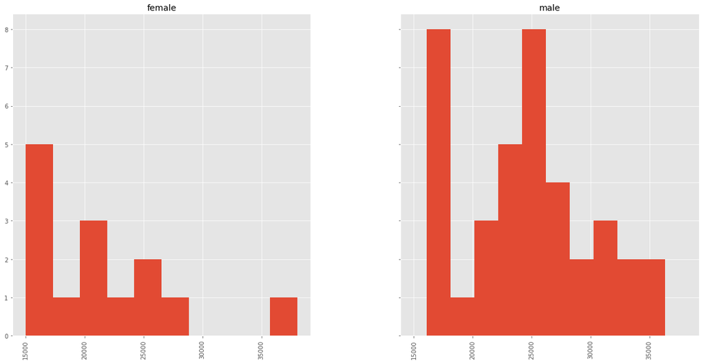

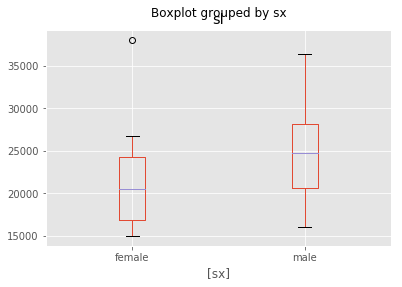

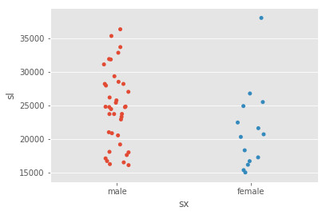

## Test for a difference in means by gender

Use a t-test to see if there is a significant difference in means

```
Ttest_indResult(statistic=array([ 1.84744028]), pvalue=array([ 0.07060394]))
```

## Descriptive Statistics by Rank

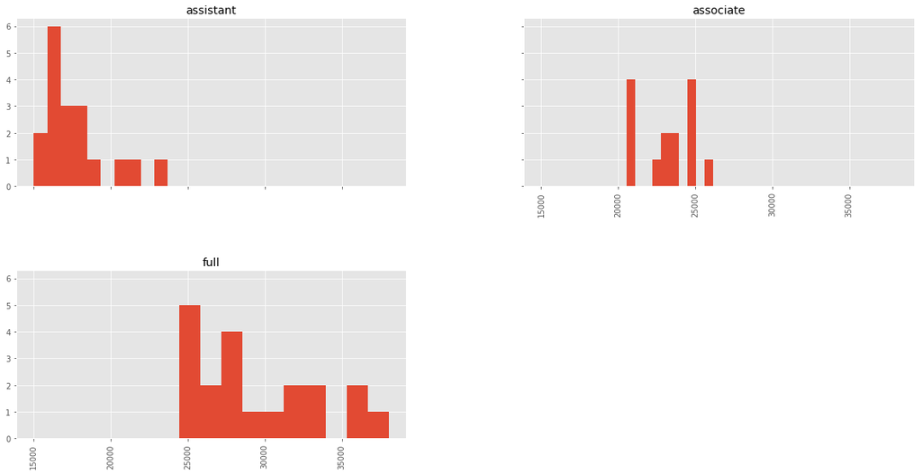

## Test for differences in means by rank

First, we'll want to leverage the **t-test** to test for differences by rank. To do this, we'll need to first break the dataset into two groups (full professors, not-full professors), then perform our t-test.

```
Ttest_indResult(statistic=array([ 9.13361444]), pvalue=array([  3.09650171e-12]))
```

Alternatively, we could use an **Analysis of Variance (ANOVA)** test to assess the statistical significance in differences across multiple groups (an extension of the t-test)

```
F_onewayResult(statistic=75.171430532471277, pvalue=1.1737811341560091e-15)
```

## How does salary (`sl`) compare to years since degress (`yd`) and years in current rank (`yr`)?

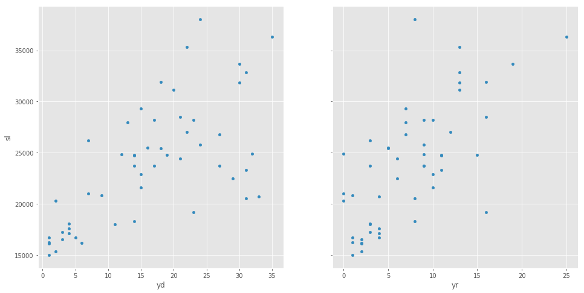

## How does salary vary across rank and sex?

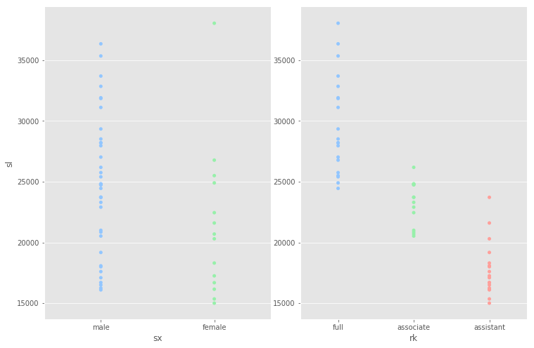

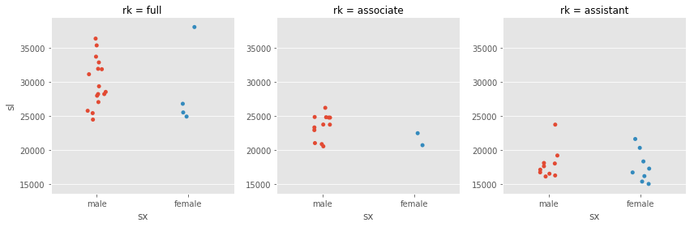